# DATA 606 Data Project: Causes of Financial Wellbeing

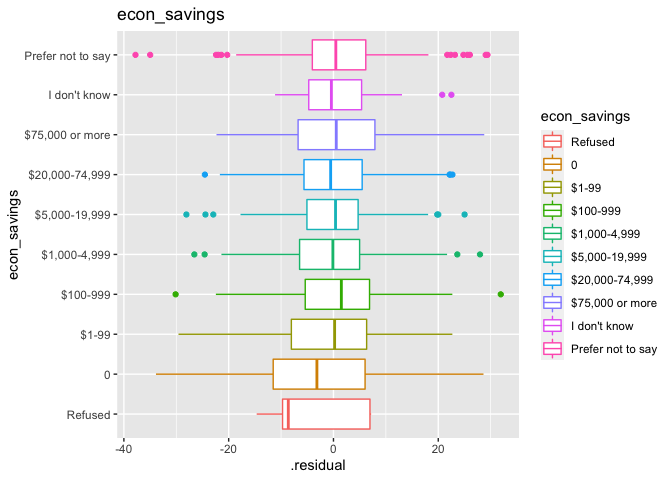

```r
# econ_savings
ggplot(data = cfpb_results) +
  geom_boxplot(mapping = aes(x=.residual, y=econ_savings, color=econ_savings)) +
  labs (title = "econ_savings")
```

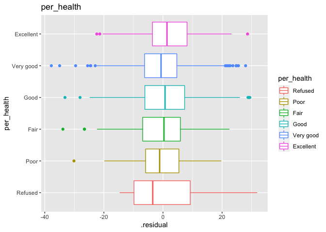

```r
# per_health
ggplot(data = cfpb_results) +
  geom_boxplot(mapping = aes(x=.residual, y=per_health, color=per_health)) +
  labs (title = "per_health")
```

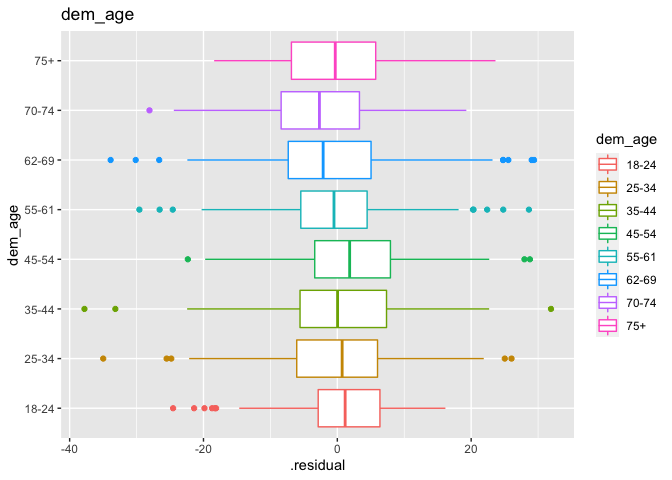

```r
# dem_age
ggplot(data = cfpb_results) +
  geom_boxplot(mapping = aes(x=.residual, y=dem_age, color=dem_age)) +
  labs (title = "dem_age")
```

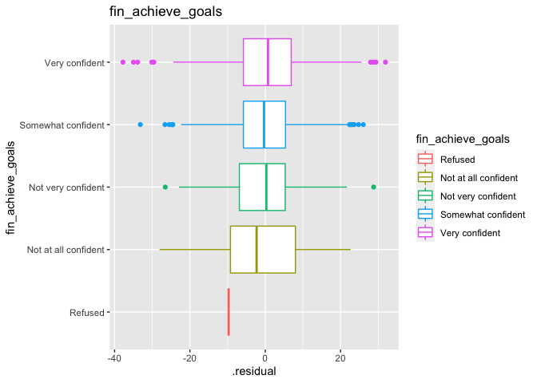

```r
# fin_achieve_goals
ggplot(data = cfpb_results) +
  geom_boxplot(mapping = aes(x=.residual, y=fin_achieve_goals, color=fin_achieve_goals)) +
  labs (title = "fin_achieve_goals")
```

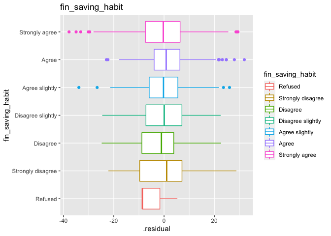

```r
# fin_saving_habit
ggplot(data = cfpb_results) +
  geom_boxplot(mapping = aes(x=.residual, y=fin_saving_habit, color=fin_saving_habit)) +
  labs (title = "fin_saving_habit")
```

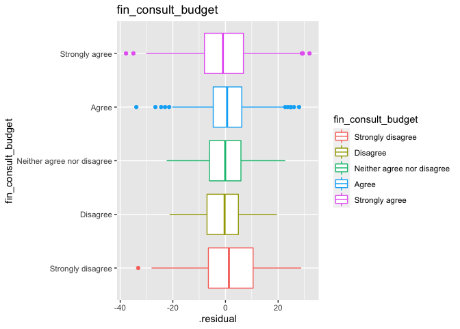

```r
# fin_consult_budget
ggplot(data = cfpb_results) +
  geom_boxplot(mapping = aes(x=.residual, y=fin_consult_budget, color=fin_consult_budget)) +
  labs (title = "fin_consult_budget")
```

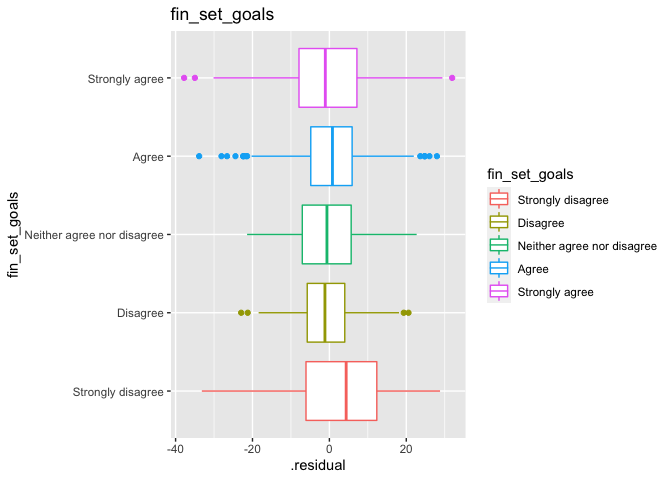

```r
# fin_set_goals
ggplot(data = cfpb_results) +
  geom_boxplot(mapping = aes(x=.residual, y=fin_set_goals, color=fin_set_goals)) +
  labs (title = "fin_set_goals")
```

## Demographic Model

The demographic model that includes race, gender and education has limited predictive power for overall cfpb score on its own It would be interesting to review the impacts of race, gender and education if we held other variables constant.

Model stats - r-squared for the model is 0.08288 - The residual analysis analysis shows several outliers that are impacting the model

```r
# Step:  AIC=22814.15
# cfpb_score ~  dem_edu + dem_race +dem_gender


# Model Specification
lm_model <- linear_reg() %>%
            set_engine('lm') %>%
            set_mode('regression')


# Fitting to Trained Data
lm_fit <- lm_model %>%
          fit(cfpb_score ~ dem_edu + dem_race + dem_gender

              , data = cfpb_training)


# Explore Training Results
names(lm_fit)
```

```
## [1] "lvl"     "spec"    "fit"     "preproc" "elapsed"
```

```r
summary(lm_fit$fit)
```

```
##
## Call:
## stats::lm(formula = cfpb_score ~ dem_edu + dem_race + dem_gender,
##     data = data)
##
## Residuals:
##     Min      1Q  Median      3Q     Max
## -45.443  -8.084  -0.120   8.121  43.702
##
## Coefficients:
##                                     Estimate Std. Error t value Pr(>|t|)
## (Intercept)                          50.3671     0.7956  63.310  < 2e-16 ***
## dem_eduHigh school degree/GED         4.7528     0.8220   5.782 7.81e-09 ***
## dem_eduSome college/Associate         5.5119     0.8098   6.807 1.11e-11 ***
## dem_eduBachelor's degree              9.7164     0.8496  11.436  < 2e-16 ***
## dem_eduGraduate/professional degree  12.6420     0.8722  14.495  < 2e-16 ***
## dem_raceBlack, Non-Hispanic          -3.4910     0.6202  -5.629 1.91e-08 ***
## dem_raceOther, Non-Hispanic          -3.4305     0.8265  -4.151 3.37e-05 ***
## dem_raceHispanic                     -3.1819     0.5671  -5.611 2.12e-08 ***
## dem_genderFemale                     -0.6401     0.3790  -1.689   0.0913 .
## ---
## Signif. codes:  0 '***' 0.001 '**' 0.01 '*' 0.05 '.' 0.1 ' ' 1
##
## Residual standard error: 13.37 on 5101 degrees of freedom
## Multiple R-squared:  0.08432,    Adjusted R-squared:  0.08288
## F-statistic: 58.72 on 8 and 5101 DF,  p-value: < 2.2e-16
```

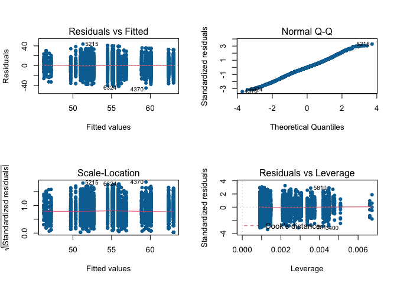

```r
par(mfrow=c(2,2))
plot(lm_fit$fit, pch = 16, col = '#006EA1')
```

```r
# Data frame of estimated coefficients
tidy(lm_fit)
```

```
## # A tibble: 9 × 5
##   term                                estimate std.error statistic  p.value
##   <chr>                                  <dbl>     <dbl>     <dbl>    <dbl>
## 1 (Intercept)                           50.4       0.796     63.3  0
## 2 dem_eduHigh school degree/GED          4.75      0.822      5.78 7.81e- 9
## 3 dem_eduSome college/Associate          5.51      0.810      6.81 1.11e-11
## 4 dem_eduBachelor's degree               9.72      0.850     11.4  6.36e-30
## 5 dem_eduGraduate/professional degree   12.6       0.872     14.5  1.09e-46
## 6 dem_raceBlack, Non-Hispanic           -3.49      0.620     -5.63 1.91e- 8
## 7 dem_raceOther, Non-Hispanic           -3.43      0.826     -4.15 3.37e- 5
## 8 dem_raceHispanic                      -3.18      0.567     -5.61 2.12e- 8
## 9 dem_genderFemale                      -0.640     0.379     -1.69 9.13e- 2
```

```r
# Performance metrics on training data
glance(lm_fit)
```

```
## # A tibble: 1 × 12
##   r.squared adj.r.squared sigma statistic  p.value    df  logLik    AIC    BIC
##       <dbl>         <dbl> <dbl>     <dbl>    <dbl> <dbl>   <dbl>  <dbl>  <dbl>
## 1    0.0843        0.0829  13.4      58.7 4.49e-92     8 -20495. 41011. 41076.
## # … with 3 more variables: deviance <dbl>, df.residual <int>, nobs <int>
```

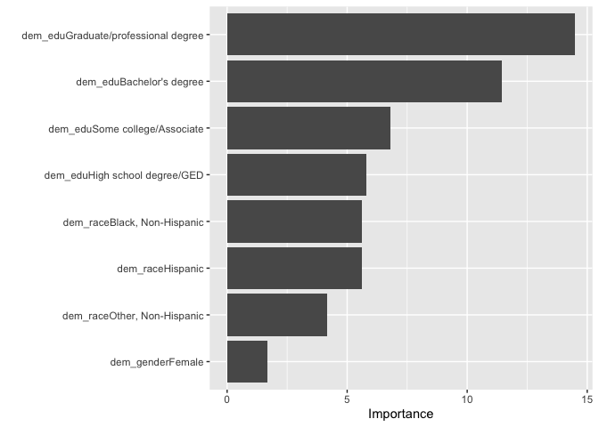

```r
# variable importance
vip(lm_fit, num_features=15)
```

**Testing Demographic Model**

```r
#predict(lm_fit, new_data = cfpb_test)

cfpb_results <- predict(lm_fit, new_data = cfpb_test) %>%
                            bind_cols(cfpb_test)

#cfpb_results

# RMSE on test set
rmse(cfpb_results, truth = cfpb_score, estimate = .pred)
```

```
## # A tibble: 1 × 3
##   .metric .estimator .estimate
##   <chr>   <chr>          <dbl>
## 1 rmse    standard        13.9
```

```r
rsq(cfpb_results, truth = cfpb_score, estimate = .pred)
```

```
## # A tibble: 1 × 3
##   .metric .estimator .estimate
##   <chr>   <chr>          <dbl>
## 1 rsq     standard      0.0749
```

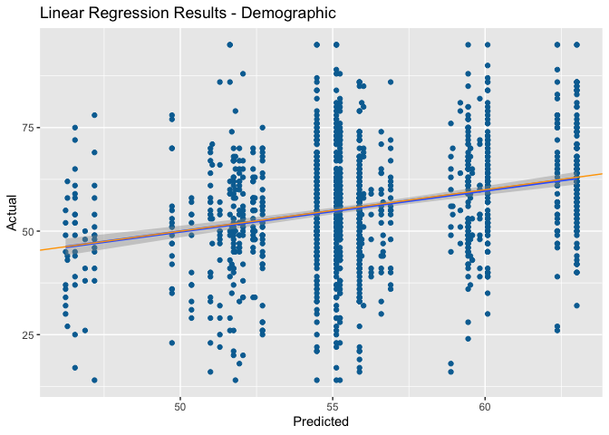

```r
ggplot(data = cfpb_results,
       mapping = aes(x = .pred, y = cfpb_score)) +
  geom_point(color = '#006EA1') +
  geom_smooth(method = lm) +
  geom_abline(intercept = 0, slope = 1, color = 'orange') +
  labs(title = 'Linear Regression Results - Demographic',
       x = 'Predicted',
       y = 'Actual')
```

## Financial Planning

The model that focused on financial planning, budgeting and setting goals has some explanatory power. Although 0.2717 is relativily low in comparison to the other models it is significant when considered in the context of the variable that are not included such as income, education and age.

Model stats - r-squared for the model is 0.2717 - The residual analysis analysis shows several outliers that are impacting the model

```r
# Step:  AIC=22814.15
# cfpb_score ~  fin_goals + fin_saving_habit + fin_frugal +
#                       fin_consult_budget + fin_follow_budget + fin_set_goals + fin_clear_plan


# Model Specification
lm_model <- linear_reg() %>%
            set_engine('lm') %>%
            set_mode('regression')


# Fitting to Trained Data
lm_fit <- lm_model %>%
          fit(cfpb_score ~ fin_goals + fin_saving_habit + fin_frugal + fin_consult_budget +
                  fin_follow_budget + fin_set_goals + fin_clear_plan

              , data = cfpb_training)


# Explore Training Results
names(lm_fit)
```

```
## [1] "lvl"     "spec"    "fit"     "preproc" "elapsed"
```

```r
summary(lm_fit$fit)
```

```
##
## Call:
## stats::lm(formula = cfpb_score ~ fin_goals + fin_saving_habit +
##     fin_frugal + fin_consult_budget + fin_follow_budget + fin_set_goals +
##     fin_clear_plan, data = data)
##
## Residuals:
##     Min      1Q  Median      3Q     Max
## -45.224  -7.087  -0.196   7.042  54.220
##
## Coefficients: (3 not defined because of singularities)
##                                              Estimate Std. Error t value
## (Intercept)                                   52.2624     4.9314  10.598
## fin_goalsNo                                    2.1419     1.6357   1.309
## fin_goalsYes                                   0.1991     1.6296   0.122
## fin_saving_habitStrongly disagree             -7.6011     5.3079  -1.432
## fin_saving_habitDisagree                      -2.0373     5.2728  -0.386
## fin_saving_habitDisagree slightly              0.7912     5.2671   0.150
## fin_saving_habitAgree slightly                 5.1534     5.2539   0.981
## fin_saving_habitAgree                         10.3637     5.2577   1.971
## fin_saving_habitStrongly agree                15.1631     5.2560   2.885
## fin_frugalStrongly disagree                  -17.2394     6.8211  -2.527
## fin_frugalDisagree                           -12.8933     6.4805  -1.990
## fin_frugalDisagree slightly                  -12.2969     6.2551  -1.966
## fin_frugalAgree slightly                     -13.0762     6.2088  -2.106
## fin_frugalAgree                              -11.8171     6.2016  -1.906
## fin_frugalStrongly agree                     -13.3798     6.1965  -2.159
## fin_consult_budgetStrongly disagree           21.1514     7.6840   2.753
## fin_consult_budgetDisagree                    16.6486     7.5975   2.191
## fin_consult_budgetNeither agree nor disagree  14.2768     7.5813   1.883
## fin_consult_budgetAgree                       12.7164     7.5853   1.676
## fin_consult_budgetStrongly agree              10.3244     7.5639   1.365
## fin_follow_budgetStrongly disagree            -2.7322     1.8653  -1.465
## fin_follow_budgetDisagree                      0.9328     0.9581   0.974
## fin_follow_budgetNeither agree nor disagree    0.6871     0.7849   0.875
## fin_follow_budgetAgree                         0.3698     0.6901   0.536
## fin_follow_budgetStrongly agree                    NA         NA      NA
## fin_set_goalsStrongly disagree                -6.3217     1.7734  -3.565
## fin_set_goalsDisagree                         -5.7318     0.9861  -5.813
## fin_set_goalsNeither agree nor disagree       -4.5447     0.7716  -5.890
```

[output cut: 34 more lines]

```
## fin_set_goalsDisagree                        6.52e-09 ***
## fin_set_goalsNeither agree nor disagree      4.11e-09 ***
## fin_set_goalsAgree                           2.75e-06 ***
## fin_set_goalsStrongly agree                        NA
## fin_clear_planStrongly disagree              0.000440 ***
## fin_clear_planDisagree                       0.002480 **
## fin_clear_planNeither agree nor disagree     0.001265 **
## fin_clear_planAgree                          0.037212 *
## fin_clear_planStrongly agree                       NA
## ---
## Signif. codes:  0 '***' 0.001 '**' 0.01 '*' 0.05 '.' 0.1 ' ' 1
##
## Residual standard error: 11.91 on 5078 degrees of freedom
## Multiple R-squared:  0.2761, Adjusted R-squared:  0.2717
## F-statistic: 62.47 on 31 and 5078 DF,  p-value: < 2.2e-16
```

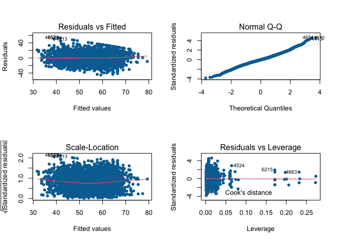

```r
par(mfrow=c(2,2))
plot(lm_fit$fit, pch = 16, col = '#006EA1')
```

```r
# Data frame of estimated coefficients
tidy(lm_fit)
```

```
## # A tibble: 35 × 5
##    term                              estimate std.error statistic  p.value
##    <chr>                                <dbl>     <dbl>     <dbl>    <dbl>
##  1 (Intercept)                         52.3        4.93    10.6   5.69e-26
##  2 fin_goalsNo                          2.14       1.64     1.31  1.90e- 1
##  3 fin_goalsYes                         0.199      1.63     0.122 9.03e- 1
##  4 fin_saving_habitStrongly disagree   -7.60       5.31    -1.43  1.52e- 1
##  5 fin_saving_habitDisagree            -2.04       5.27    -0.386 6.99e- 1
##  6 fin_saving_habitDisagree slightly    0.791      5.27     0.150 8.81e- 1
##  7 fin_saving_habitAgree slightly       5.15       5.25     0.981 3.27e- 1
##  8 fin_saving_habitAgree               10.4        5.26     1.97  4.88e- 2
##  9 fin_saving_habitStrongly agree      15.2        5.26     2.88  3.93e- 3
## 10 fin_frugalStrongly disagree        -17.2        6.82    -2.53  1.15e- 2
## # … with 25 more rows
```

```r
# Performance metrics on training data
glance(lm_fit)
```

```
## # A tibble: 1 × 12
##   r.squared adj.r.squared sigma statistic p.value    df  logLik    AIC    BIC
##       <dbl>         <dbl> <dbl>     <dbl>   <dbl> <dbl>   <dbl>  <dbl>  <dbl>
## 1     0.276         0.272  11.9      62.5       0    31 -19895. 39856. 40072.
## # … with 3 more variables: deviance <dbl>, df.residual <int>, nobs <int>
```

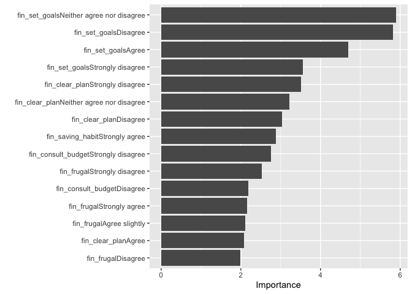

```r
# variable importance
vip(lm_fit, num_features=15)
```

**Testing Financial Planning Model**

```r
#predict(lm_fit, new_data = cfpb_test)

cfpb_results <- predict(lm_fit, new_data = cfpb_test) %>%
                            bind_cols(cfpb_test)
#cfpb_results

# RMSE on test set
rmse(cfpb_results, truth = cfpb_score, estimate = .pred)
```

```
## # A tibble: 1 × 3
##   .metric .estimator .estimate
##   <chr>   <chr>          <dbl>
## 1 rmse    standard        12.4
```

```r
rsq(cfpb_results, truth = cfpb_score, estimate = .pred)
```

```
## # A tibble: 1 × 3
##   .metric .estimator .estimate
##   <chr>   <chr>          <dbl>
## 1 rsq     standard       0.274
```

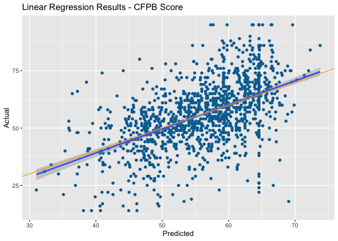

```r
ggplot(data = cfpb_results,
       mapping = aes(x = .pred, y = cfpb_score)) +
  geom_point(color = '#006EA1') +
  geom_smooth(method = lm) +
  geom_abline(intercept = 0, slope = 1, color = 'orange') +
  labs(title = 'Linear Regression Results - CFPB Score',
       x = 'Predicted',
       y = 'Actual')
```

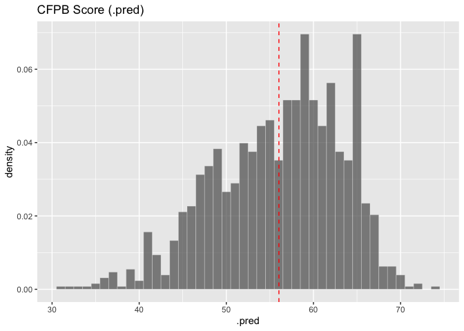

```r
# age category

cfpb_results$cfpb_score_10cat <- cut(cfpb_results$cfpb_score, breaks = c(-10, 10, 20, 30, 40, 50, 60, 70, 80, 90, 100),
                           labels = c("< 10","10-20","20-30","30-40","40-50","50-60","60-70","70-80","80-90","90-100"),
                           right = FALSE,
                           include.lowest=TRUE)

t <- cfpb_results %>% select(cfpb_score,cfpb_score_10cat)

ggplot(cfpb_results,
    aes(.pred, y = stat(density))) +
    geom_histogram(binwidth = 1, alpha = 0.7, bins = 100, color="white",size = 0.1) +
    geom_vline(aes(xintercept = mean(.pred)), linetype = "dashed", color="red", size = 0.5) +
    scale_fill_brewer(palette="Spectral") +
    labs(title = "CFPB Score (.pred)")
```

```r
summary(cfpb_df$.pred)
```

```
## Length  Class   Mode
##      0   NULL   NULL
```

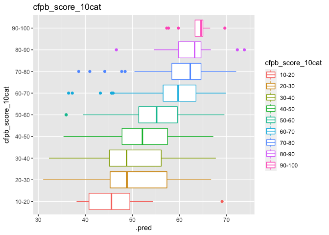

```r
ggplot(data = cfpb_results) +
  geom_boxplot(mapping = aes(x=.pred, y=cfpb_score_10cat, color=cfpb_score_10cat)) +
  labs (title = "cfpb_score_10cat")
```

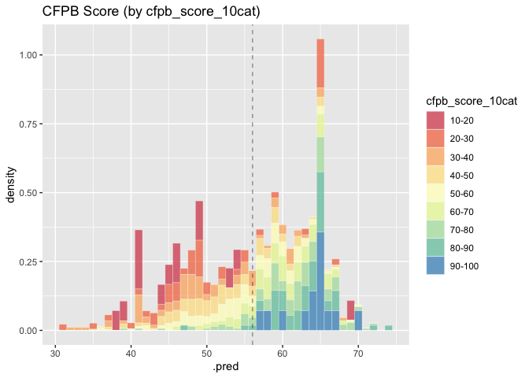

```r
ggplot(cfpb_results,
    aes(.pred, fill = cfpb_score_10cat, y = stat(density))) +
    geom_histogram(binwidth = 1, alpha = 0.7, bins = 100, color="white",size = 0.1) +
    geom_vline(aes(xintercept = mean(.pred)), linetype = "dashed", size = 0.2) +
    scale_fill_brewer(palette="Spectral") +
    labs(title = "CFPB Score (by cfpb_score_10cat)")
```

# Part 5 - Conclusion

A linear regression model was developed using the results of the Consumer Financial Protection Bureau’s (CFPB) National Financial Well-Being Survey Public Use File (PUF). The model predicts over 0.5608 cfpb score given the 8 variable selected for the optimized model.

**Model Performance** - adjusted $R^2$ 0.5608655  
- root mean square error 9.609951

**Model Variables** The following variable are included in the model as significant contributors to the overall model accuracy.

- econ_hh_income (PPINCIMP) - The survey respondents Household Income for a given year.
- econ_savings (SAVINGSRANGES) - An assessment of the amount of savings that the survey respondant currenlty has.
- per_health (HEALTH) - An assessment of the survey respondents overall health.
- dem_age (agecat) - The age of the survey respondent (8 categories).
- fin_achieve_goals (GOALCONF) - An assessment of the ability of the survey respondent to achieve their financial goals.
- fin_saving_habit (SAVEHABIT) - An assessment of savings habits and how often money is put away.
- fin_consult_budget (PROPPLAN_1) - An assessment of how budgeting impacts spending decisions.
- fin_set_goals (PROPPLAN_3) - An assessment of financial planning and goal setting discipline.

The findings for the analysis are not surprising and are consistent with several studies in the industry however deeper analysis is warranted. The cfpb scaled score is designed to cover the entire population however it is not surprising that the resulting model breaks down slightly at the higher and lower ranges of the cfpb score. A more localized analysis of cfpb score ranges might provide some additional insight into the factors that impact consumer financial wellness.

# References

- Consumer Financial Protection Bureau - Financial Wellness Survey [*Financial well-being data*](https://www.consumerfinance.gov/data-research/financial-well-being-survey-data/) The PUF survey results can be accessed as a csv file [*Financial well-being survey data*](https://www.consumerfinance.gov/documents/5614/NFWBS_PUF_2016_data.csv)

# Appendix (optional)

## CFPB Financial Well-Being Scale Methodology

The CFPB Financial Well-Being Scale methodology uses the following 10 questions to calculate the cfpb score. There is some overlap between the questions used to calculate the cfpb score and the survey questions. The optimized models presented in this analysis did not include any of the variable that overlap with the scoring questions.

How well does this statement describe you or your situation?

1. I could handle a major unexpected expense
2. I am securing my financial future
3. Because of my money situation, I feel like I will never have the things I want in life*
4. I can enjoy life because of the way I’m managing my money
5. I am just getting by financially*
6. I am concerned that the money I have or will save won’t last*

How often does this statement apply to you?

7. Giving a gift for a wedding, birthday or other occasion would put a strain on my finances for the month*
8. I have money left over at the end of the month
9. I am behind with my finances*
10. My finances control my life*

The research question is clearly stated, can be answered by the data, and the context of the problem clearly explained.

## Review of the variables

The PUF includes financial attitude that were not included as part of the analysis but provide a interesting window into the relationship of financial attitudes to consumer financial wellbeing.

```r
result_df <- getResultsCFPBFile()
result_df <- result_df %>% filter( cfpb_score > 0)
```

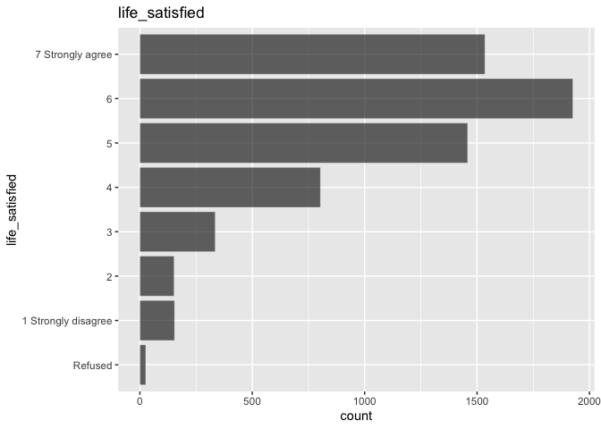

```r
# life_satisfied
ggplot(result_df, aes(x=life_satisfied)) +
  geom_bar(color="white", fill="black", alpha = 0.6, size = 0.1) +
  coord_flip() +
  labs(title = "life_satisfied")
```

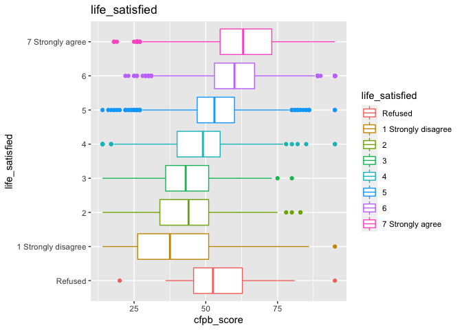

```r
ggplot(data = result_df) +
  geom_boxplot(mapping = aes(x=cfpb_score, y=life_satisfied, color=life_satisfied)) +
  labs (title = "life_satisfied")
```

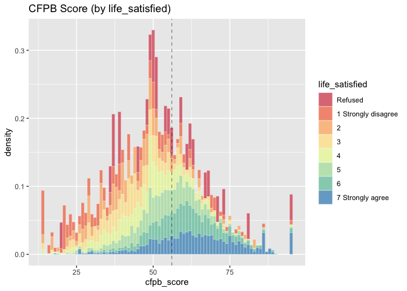

```r
ggplot(result_df,
    aes(cfpb_score, fill = life_satisfied, y = stat(density))) +
    geom_histogram(binwidth = 1, alpha = 0.7, bins = 100, color="white",size = 0.1) +
    geom_vline(aes(xintercept = mean(cfpb_score)), linetype = "dashed", size = 0.2) +
    scale_fill_brewer(palette="Spectral") +
    labs(title = "CFPB Score (by life_satisfied)")
```

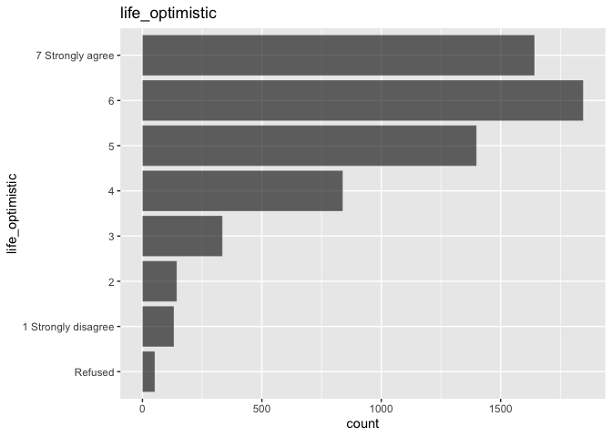

```r
# life_optimistic
ggplot(result_df, aes(x=life_optimistic)) +
  geom_bar(color="white", fill="black", alpha = 0.6, size = 0.1) +
  coord_flip() +
  labs(title = "life_optimistic")
```

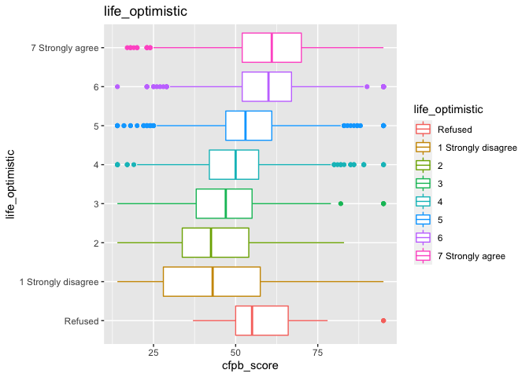

```r
ggplot(data = result_df) +
  geom_boxplot(mapping = aes(x=cfpb_score, y=life_optimistic, color=life_optimistic)) +
  labs (title = "life_optimistic")
```

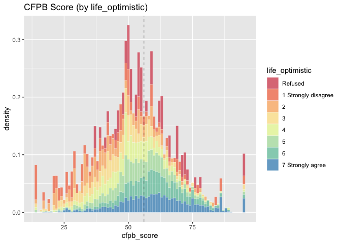

```r
ggplot(result_df,
    aes(cfpb_score, fill = life_optimistic, y = stat(density))) +
    geom_histogram(binwidth = 1, alpha = 0.7, bins = 100, color="white",size = 0.1) +
    geom_vline(aes(xintercept = mean(cfpb_score)), linetype = "dashed", size = 0.2) +
    scale_fill_brewer(palette="Spectral") +
    labs(title = "CFPB Score (by life_optimistic)")
```

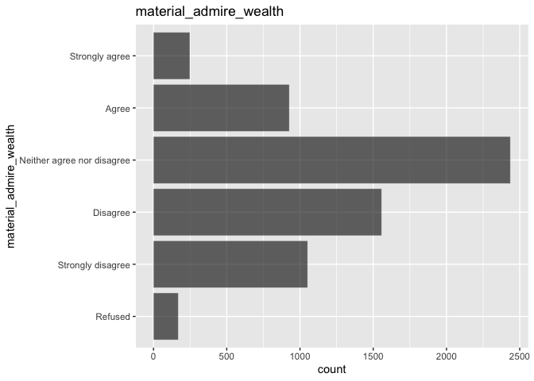

```r
# material_admire_wealth
ggplot(result_df, aes(x=material_admire_wealth)) +
  geom_bar(color="white", fill="black", alpha = 0.6, size = 0.1) +
  coord_flip() +
  labs(title = "material_admire_wealth")
```

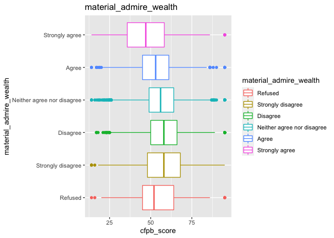

```r
ggplot(data = result_df) +
  geom_boxplot(mapping = aes(x=cfpb_score, y=material_admire_wealth, color=material_admire_wealth)) +
  labs (title = "material_admire_wealth")
```

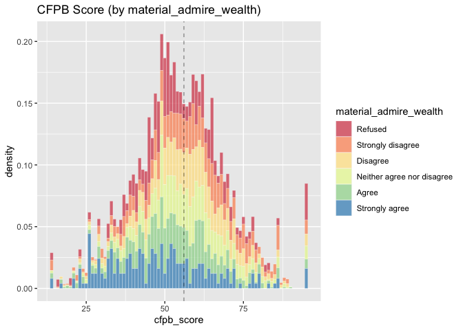

```r
ggplot(result_df,
    aes(cfpb_score, fill = material_admire_wealth, y = stat(density))) +
    geom_histogram(binwidth = 1, alpha = 0.7, bins = 100, color="white",size = 0.1) +
    geom_vline(aes(xintercept = mean(cfpb_score)), linetype = "dashed", size = 0.2) +
    scale_fill_brewer(palette="Spectral") +
    labs(title = "CFPB Score (by material_admire_wealth)")
```

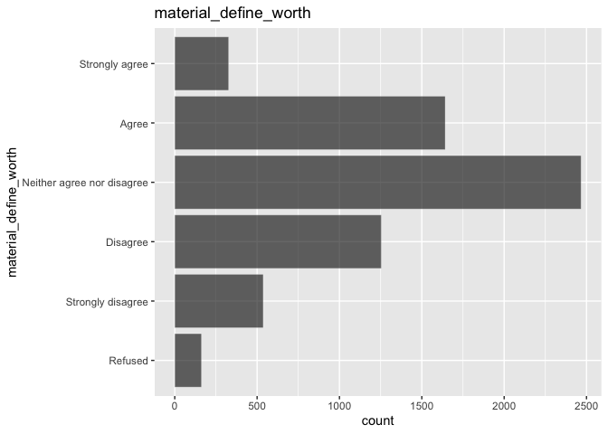

```r
# material_define_worth
ggplot(result_df, aes(x=material_define_worth)) +
  geom_bar(color="white", fill="black", alpha = 0.6, size = 0.1) +
  coord_flip() +
  labs(title = "material_define_worth")
```

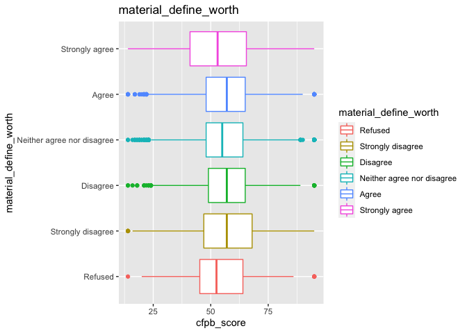

```r
ggplot(data = result_df) +
  geom_boxplot(mapping = aes(x=cfpb_score, y=material_define_worth, color=material_define_worth)) +
  labs (title = "material_define_worth")
```

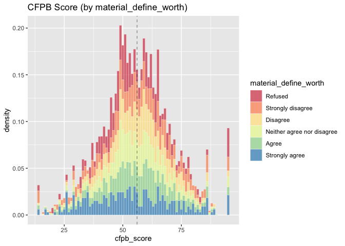

```r
ggplot(result_df,
    aes(cfpb_score, fill = material_define_worth, y = stat(density))) +
    geom_histogram(binwidth = 1, alpha = 0.7, bins = 100, color="white",size = 0.1) +
    geom_vline(aes(xintercept = mean(cfpb_score)), linetype = "dashed", size = 0.2) +
    scale_fill_brewer(palette="Spectral") +
    labs(title = "CFPB Score (by material_define_worth)")
```

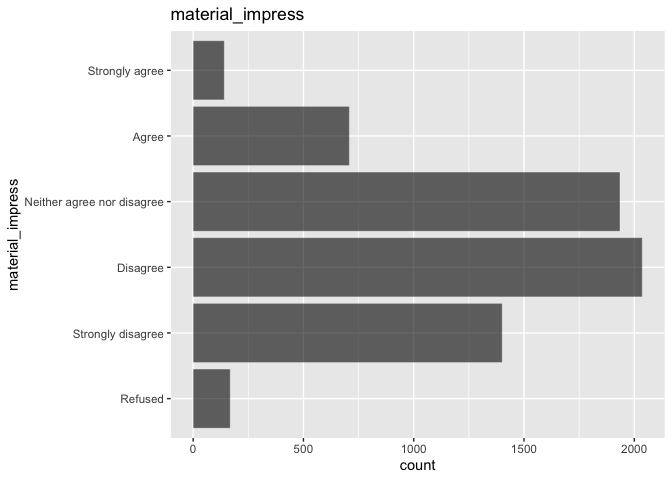

```r
# material_impress
ggplot(result_df, aes(x=material_impress)) +
  geom_bar(color="white", fill="black", alpha = 0.6, size = 0.1) +
  coord_flip() +
  labs(title = "material_impress")
```

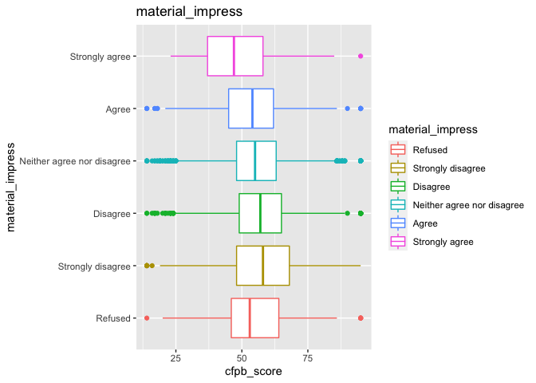

```r
ggplot(data = result_df) +
  geom_boxplot(mapping = aes(x=cfpb_score, y=material_impress, color=material_impress)) +
  labs (title = "material_impress")
```

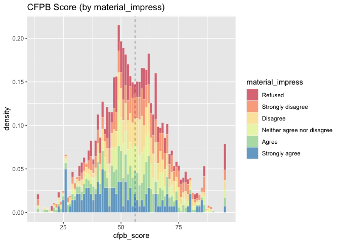

```r
ggplot(result_df,
    aes(cfpb_score, fill = material_impress, y = stat(density))) +
    geom_histogram(binwidth = 1, alpha = 0.7, bins = 100, color="white",size = 0.1) +
    geom_vline(aes(xintercept = mean(cfpb_score)), linetype = "dashed", size = 0.2) +
    scale_fill_brewer(palette="Spectral") +
    labs(title = "CFPB Score (by material_impress)")
```